# part5

me

12 joulukuuta 2019

# 4. Traits analyysi

Selvitetään ovatko tietyt lajiominaisuudet kytköksissä ennustustarkkuuteen.  
Analysoin pa ja abu-aineistot erillään.

## 4.1 Aineisto sisään ja taulukoiden kokoaminen

Log-muunnetaan prevalenssi ja massa.

```r
#aineiston valinta, leväyttäminen ja uudelleen nimeäminen
poolres<-read.csv("poolres.csv")

#lisätään lajiominaisuudet taulukkoon
traits<-read.csv("traits_table.csv",sep = ";")
results<-inner_join(poolres,traits,by="species")
str(results)
```

```
## 'data.frame':    1920 obs. of  9 variables:
##  $ species : chr  "Acrocephalus_palustris" "Acrocephalus_schoenobaenus" "Acrocephalus_scirpaceus" "Actitis_hypoleucos" ...
##  $ method  : Factor w/ 4 levels "A","B","C","D": 1 1 1 1 1 1 1 1 1 1 ...
##  $ accuracy: num  0.525 0.232 0.316 0.292 0.402 ...
##  $ pa      : Factor w/ 2 levels "abu","pa": 1 1 1 1 1 1 1 1 1 1 ...
##  $ pool    : Factor w/ 2 levels "NPo","Po": 1 1 1 1 1 1 1 1 1 1 ...
##  $ Mig     : Factor w/ 3 levels "L","R","S": 1 1 1 1 2 3 3 3 3 3 ...
##  $ Hab     : Factor w/ 4 levels "CU","FO","MM",..: 4 4 4 4 2 1 4 4 4 3 ...
##  $ Mass    : num  12 12 13 47.5 8 ...
##  $ Prev    : num  0.0818 0.1246 0.1479 0.3026 0.1321 ...
```

```r
results$species=as.factor(results$species)

#uusi muuttuja, massan logaritmi
results$logmass<-log(results$Mass)

#uusi muuttuja, log-muunnettu prevalenssi
results$PrevS=log(results$Prev)

#arcsin-muunnos (kokeiltu)
#asinTransform <- function(p) { asin(sqrt(p)) }
#results$PrevS=asinTransform(results$Prev)

#logit-muunnos (kokeilin, antaa ihan samanlaiset residuaalit)
#logitTransform <- function(p) { log(p/(1-p)) }
#results$PrevS=logitTransform(results$Prev)

#tallenna tarvittaessa omaksi taulukokseen
#write.csv(results,"accuracies_traits.csv",row.names = F)
```

## 4.2 Aineiston tarkastelu

Tarkastellaan aineistoa kuvaajista. Jaetaan aineisto ensin pa ja abu-aineistoihin.

```r
#jaetaan aineisto pa ja abu aineistoihin
resPA=subset(results,pa=="pa")
resABU=subset(results,pa=="abu")
```

*Habitat*

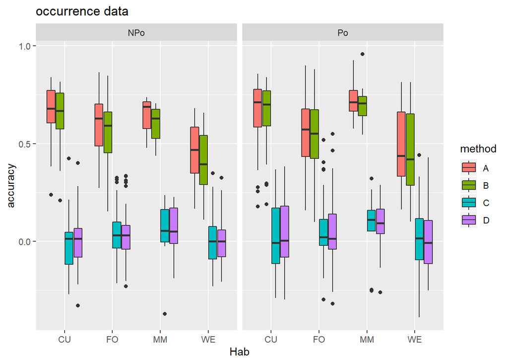

```r
ggplot(resPA, aes(x=Hab, y=accuracy)) +
  geom_boxplot(aes(fill=method)) + facet_grid(. ~pool ) +
  ggtitle("occurrence data")
```

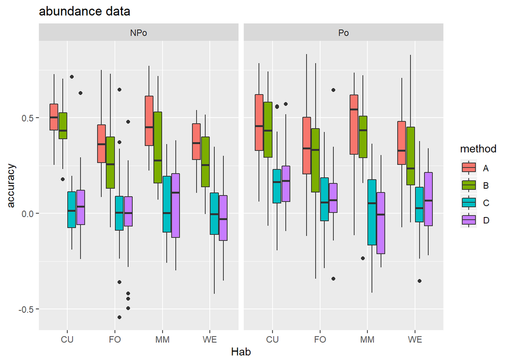

```r
ggplot(resABU, aes(x=Hab, y=accuracy)) +
  geom_boxplot(aes(fill=method)) + facet_grid(. ~pool ) +
  ggtitle("abundance data")
```

*Migration*

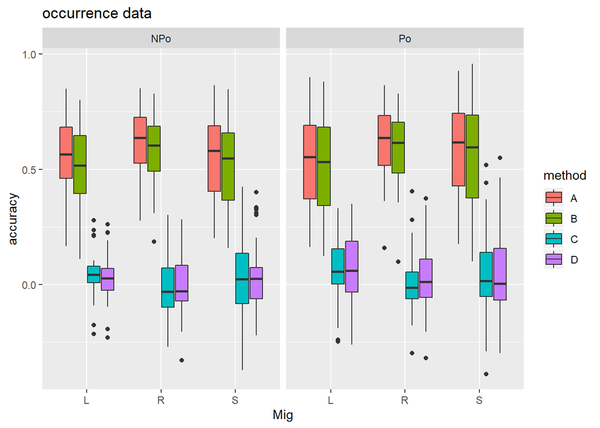

```r
#pa aineisto
ggplot(resPA, aes(x=Mig, y=accuracy)) +
  geom_boxplot(aes(fill=method))+ facet_grid(. ~pool ) +
  ggtitle("occurrence data")
```

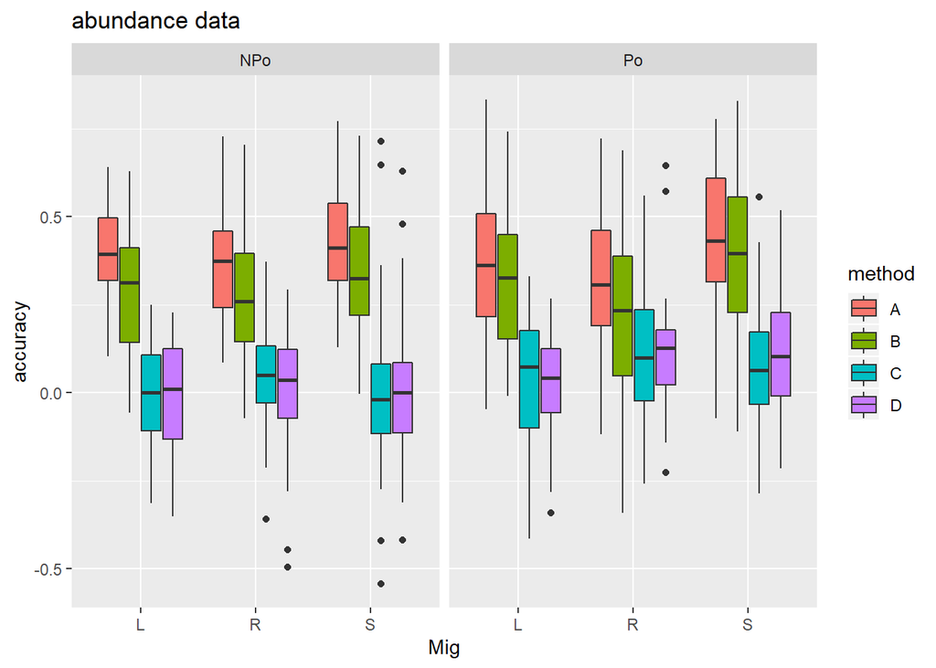

```r
ggplot(resABU, aes(x=Mig, y=accuracy)) +
  geom_boxplot(aes(fill=method))+ facet_grid(. ~pool ) +
  ggtitle("abundance data")
```

*Prevalence*

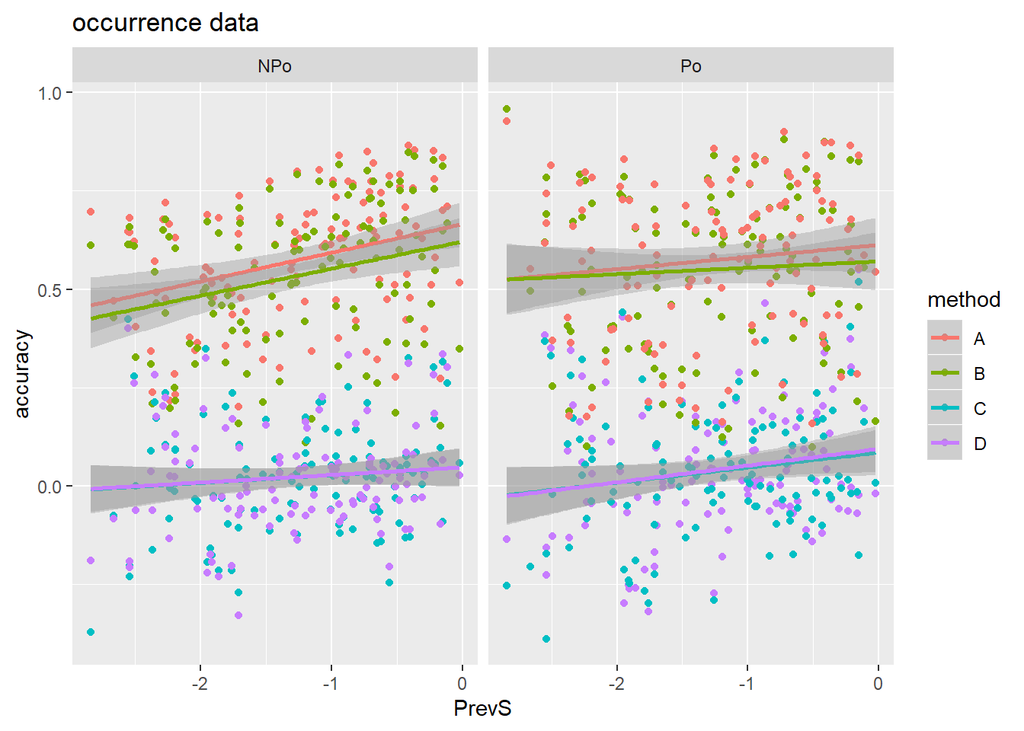

```r
#pa aineisto
ggplot(resPA, aes(x=PrevS, y=accuracy,color=method)) +
  geom_point () +
  geom_smooth(method=lm) +
  ggtitle("occurrence data") +
  facet_grid(. ~pool)
```

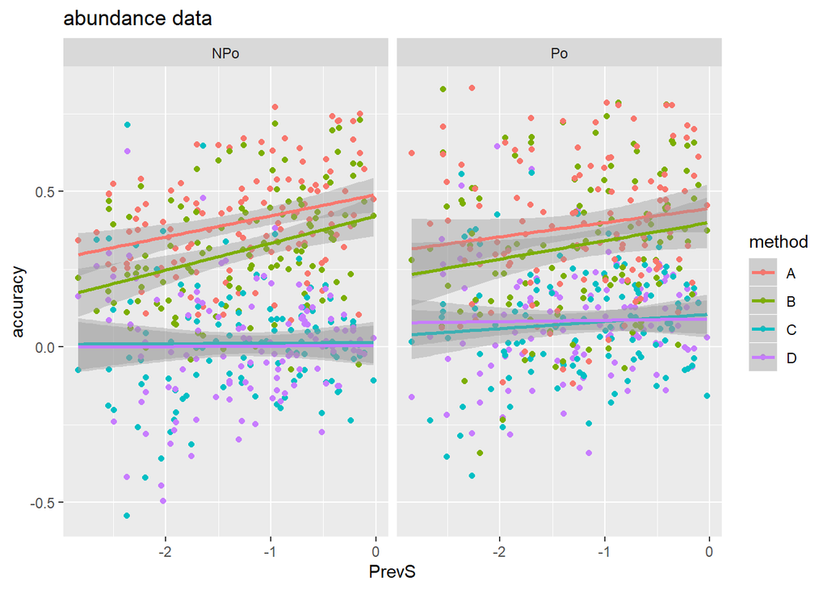

```r
#abu
ggplot(resABU, aes(x=PrevS, y=accuracy,color=method)) +
  geom_point()+
   geom_smooth(method=lm) +
  facet_grid(. ~pool ) +
  ggtitle("abundance data")
```

*Mass*

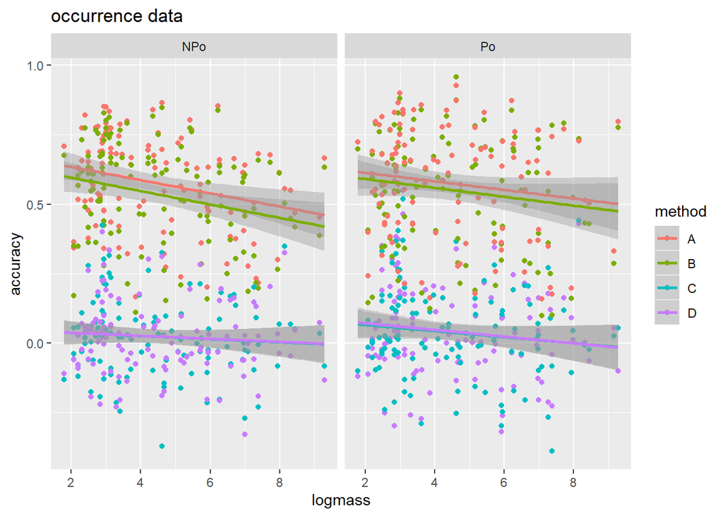

```r
#pa aineisto
ggplot(resPA, aes(x=logmass, y=accuracy,color=method)) +
  geom_point () +
  geom_smooth(method=lm) +
  ggtitle("occurrence data") +
  facet_grid(. ~pool)
```

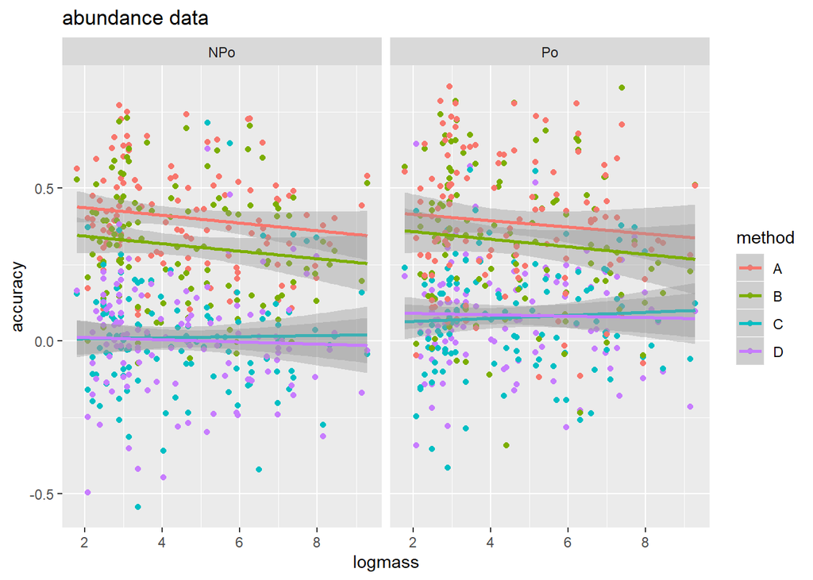

```r
#abu
ggplot(resABU, aes(x=logmass, y=accuracy,color=method)) +
  geom_point()+
   geom_smooth(method=lm) +
  facet_grid(. ~pool ) +
  ggtitle("abundance data")
```

Tarkistan massan ja prevalenssin korrelaation:

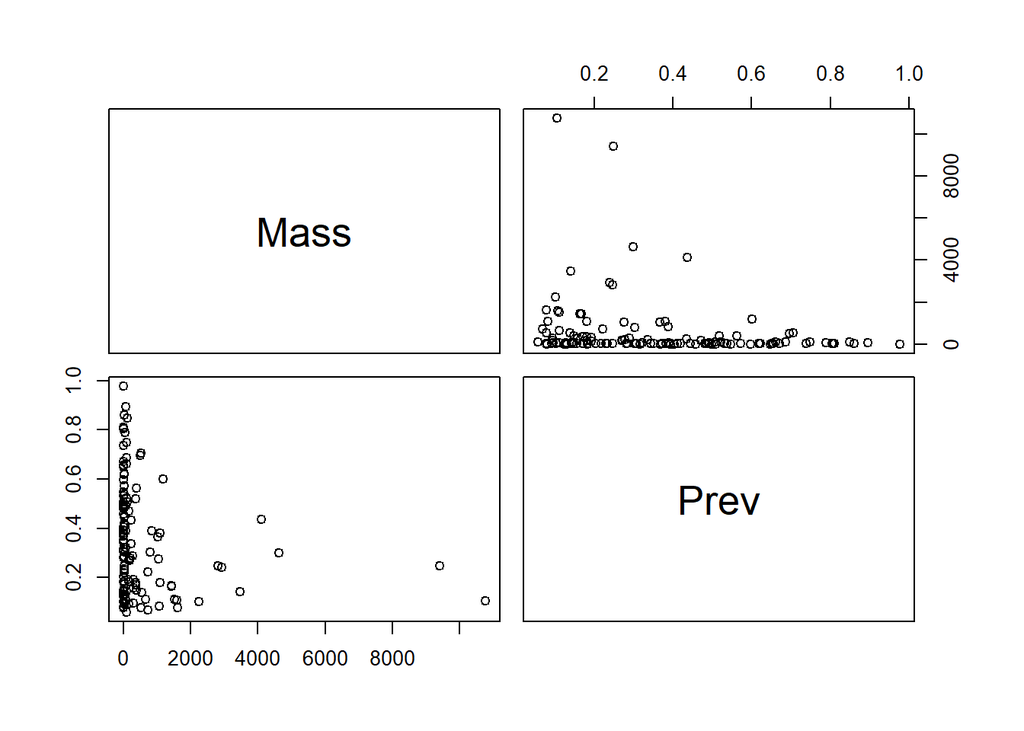

```r
pairs(results[8:9])
```

```r
cor(results$logmass,results$PrevS)
```

```
## [1] -0.3171843
```

Massa ja yleisyys eivät näytä korreloivan suuresti.

## 4.3 Fylogenia

BirdTree.org palvelusta on haettu lintujen sukupuu (tai itseasiassa tiedosto sisältää 100 vaihtoehtoista sukupuuta, joista valitaan yksi).

MCMCglmm-funktio vaatii fylogenian tietyssä rakenteessa:

ginverse= a list of sparse inverse matrices (A−1) that are proportional to the covariance structure of the random effects. The names of the matrices should correspond to columns in data that are associated with the random term. All levels of the random term should appear as rownames for the matrices.

```r
#luetaan aineisto sisään, Multiphylo eli monta puuta
linnut <- read.nexus("output.nex")
#valitaan vain yksi puu, mikä tahansa sadasta
linnut2<-linnut[[99]]
#tehdään puusta malliin sopiva fylogeniarakenne
bm.birds<-inverseA(linnut2)$Ainv
```

## 4.4 Analyysit MCMCglmm

Selvitetään, vaikuttavatko lajien ominaisuudet (muuttokäyttäytyminen ‘Mig’, elinympäristö ‘Hab’, paino ‘logMass’ tai prevalenssi ‘Prev’) ennustustarkkuuteen. Analyysissä pitäisi huomioida fylogenia eli, että lajit voivat olla ominaisuuksiltaan samankaltaisia (ja siten omata myös samanlaiset ennustustarkkuudet) läheisen sukulaisuussuhteen takia. Mukana nyt myös ominaisuuksien mahdolliset yhdysvaikutukset metodin ja poolauksen kanssa.

### 4.4.1 Pa-aineisto

Luodaan mallivaihtoehdot.

```r
#priori
#prior<-list(R=list(V=1, nu=0.00), G=list(G1=list(V=1, nu=0.00))) #mutta tämä ei nyt ole malleissa mukana (?)

#m1<- MCMCglmm(accuracy ~ Hab*method*pool + PrevS*method*pool + Mig*method*pool + logmass*method*pool, random=~species, data = resPA,family="gaussian",ginverse=list(species=bm.birds),nitt=1003000, burnin=3000, thin=1000)

#m2<- MCMCglmm(accuracy ~ Hab*method + Hab*pool +PrevS*method + PrevS*pool + Mig*method + Mig*pool + logmass*method + logmass*pool, random=~ species, data = resPA,family="gaussian",ginverse=list(species=bm.birds),nitt=1003000, burnin=3000, thin=1000)

#m3<- MCMCglmm(accuracy~ Hab*method +PrevS*method + Mig*method + logmass*method + pool, random=~species, data = resPA,family="gaussian",ginverse=list(species=bm.birds),nitt=1003000, burnin=3000, thin=1000)

#m4<- MCMCglmm(accuracy ~ Hab*pool +PrevS*pool + Mig*pool + logmass*pool + method, random=~species, data = resPA,family="gaussian",ginverse=list(species=bm.birds),nitt=1003000, burnin=3000, thin=1000)

#m5<- MCMCglmm(accuracy ~ Hab + PrevS + Mig + logmass + method + pool, random=~species, data = resPA,family="gaussian",ginverse=list(species=bm.birds),nitt=1003000, burnin=3000, thin=1000)

#m6<- MCMCglmm(accuracy ~ Hab*method +PrevS*method + Mig*method  + pool, random=~species, data = resPA,family="gaussian",ginverse=list(species=bm.birds),nitt=1003000, burnin=3000, thin=1000)

#m7<- MCMCglmm(accuracy ~ Hab*method +PrevS*method  + logmass*method + pool, random=~species, data = resPA,family="gaussian",ginverse=list(species=bm.birds),nitt=1003000, burnin=3000, thin=1000)

#m8<- MCMCglmm(accuracy ~ Hab*method + Mig*method + logmass*method + pool, random=~species, data = resPA,family="gaussian",ginverse=list(species=bm.birds),nitt=1003000, burnin=3000, thin=1000)

#m9<- MCMCglmm(accuracy ~ Prev*method + Mig*method + logmass*method + pool, random=~species, data = resPA,family="gaussian",ginverse=list(species=bm.birds),nitt=1003000, burnin=3000, thin=1000)

#m10<- MCMCglmm(accuracy ~ Hab*method +PrevS*method + pool, random=~species, data = resPA,family="gaussian",ginverse=list(species=bm.birds),nitt=1003000, burnin=3000, thin=1000)

#m11<- MCMCglmm(accuracy ~ Hab*method + Mig*method  + pool, random=~species, data = resPA,family="gaussian",ginverse=list(species=bm.birds),nitt=1003000, burnin=3000, thin=1000)

#m12<- MCMCglmm(accuracy ~ Hab*method + logmass*method + pool, random=~species, data=      resPA,family="gaussian",ginverse=list(species=bm.birds),nitt=1003000, burnin=3000, thin=1000)

#m13<- MCMCglmm(accuracy ~ PrevS*method + Mig*method  + pool, random=~species, data = resPA,family="gaussian",ginverse=list(species=bm.birds),nitt=1003000, burnin=3000, thin=1000)

#m14<- MCMCglmm(accuracy ~ PrevS*method +  logmass*method + pool, random=~species, data = resPA,family="gaussian",ginverse=list(species=bm.birds),nitt=1003000, burnin=3000, thin=1000)

#m15<- MCMCglmm(accuracy ~ Mig*method + logmass*method + pool, random=~species, data = resPA,family="gaussian",ginverse=list(species=bm.birds),nitt=1003000, burnin=3000, thin=1000)

#m16<- MCMCglmm(accuracy ~ Hab*method + pool, random=~species, data = resPA,family="gaussian",ginverse=list(species=bm.birds),nitt=1003000, burnin=3000, thin=1000)

#m17<- MCMCglmm(accuracy ~ PrevS*method + pool, random=~species, data = resPA,family="gaussian",ginverse=list(species=bm.birds),nitt=1003000, burnin=3000, thin=1000)

#m18<- MCMCglmm(accuracy ~ Mig*method  + pool, random=~species, data = resPA,family="gaussian",ginverse=list(species=bm.birds),nitt=1003000, burnin=3000, thin=1000)

#m19<- MCMCglmm(accuracy ~ logmass*method + pool, random=~species, data = resPA,family="gaussian",ginverse=list(species=bm.birds),nitt=1003000, burnin=3000, thin=1000)
```

```r
#priori
#prior<-list(R=list(V=1, nu=0.00), G=list(G1=list(V=1, nu=0.00))) #mutta tämä ei nyt ole malleissa mukana (?)

m1<- MCMCglmm(accuracy ~ Hab*method*pool + PrevS*method*pool + Mig*method*pool + logmass*method*pool, random=~species, data = resPA,family="gaussian",ginverse=list(species=bm.birds),nitt=1003000, burnin=3000, thin=1000)

m2<- MCMCglmm(accuracy ~ Hab*method + Hab*pool +PrevS*method + PrevS*pool + Mig*method + Mig*pool + logmass*method + logmass*pool, random=~ species, data = resPA,family="gaussian",ginverse=list(species=bm.birds),nitt=1003000, burnin=3000, thin=1000)

m3<- MCMCglmm(accuracy~ Hab*method +PrevS*method + Mig*method + logmass*method + pool, random=~species, data = resPA,family="gaussian",ginverse=list(species=bm.birds),nitt=1003000, burnin=3000, thin=1000)

m4<- MCMCglmm(accuracy ~ Hab*pool +PrevS*pool + Mig*pool + logmass*pool + method, random=~species, data = resPA,family="gaussian",ginverse=list(species=bm.birds),nitt=1003000, burnin=3000, thin=1000)

m5<- MCMCglmm(accuracy ~ Hab + PrevS + Mig + logmass + method + pool, random=~species, data = resPA,family="gaussian",ginverse=list(species=bm.birds),nitt=1003000, burnin=3000, thin=1000)

m6<- MCMCglmm(accuracy ~ Hab*method +PrevS*method + Mig*method  + pool, random=~species, data = resPA,family="gaussian",ginverse=list(species=bm.birds),nitt=1003000, burnin=3000, thin=1000)

m7<- MCMCglmm(accuracy ~ Hab*method +PrevS*method  + logmass*method + pool, random=~species, data = resPA,family="gaussian",ginverse=list(species=bm.birds),nitt=1003000, burnin=3000, thin=1000)

m8<- MCMCglmm(accuracy ~ Hab*method + Mig*method + logmass*method + pool, random=~species, data = resPA,family="gaussian",ginverse=list(species=bm.birds),nitt=1003000, burnin=3000, thin=1000)

m9<- MCMCglmm(accuracy ~ PrevS*method + Mig*method + logmass*method + pool, random=~species, data = resPA,family="gaussian",ginverse=list(species=bm.birds),nitt=1003000, burnin=3000, thin=1000)

m10<- MCMCglmm(accuracy ~ Hab*method +PrevS*method + pool, random=~species, data = resPA,family="gaussian",ginverse=list(species=bm.birds),nitt=1003000, burnin=3000, thin=1000)

m11<- MCMCglmm(accuracy ~ Hab*method + Mig*method  + pool, random=~species, data =
resPA,family="gaussian",ginverse=list(species=bm.birds),nitt=1003000, burnin=3000, thin=1000)

m12<- MCMCglmm(accuracy ~ Hab*method + logmass*method + pool, random=~species, data=      resPA,family="gaussian",ginverse=list(species=bm.birds),nitt=1003000, burnin=3000, thin=1000)

m13<- MCMCglmm(accuracy ~ PrevS*method + Mig*method  + pool, random=~species, data = resPA,family="gaussian",ginverse=list(species=bm.birds),nitt=1003000, burnin=3000, thin=1000)

m14<- MCMCglmm(accuracy ~ PrevS*method +  logmass*method + pool, random=~species, data = resPA,family="gaussian",ginverse=list(species=bm.birds),nitt=1003000, burnin=3000, thin=1000)

m15<- MCMCglmm(accuracy ~ Mig*method + logmass*method + pool, random=~species, data = resPA,family="gaussian",ginverse=list(species=bm.birds),nitt=1003000, burnin=3000, thin=1000)

m16<- MCMCglmm(accuracy ~ Hab*method + pool, random=~species, data = resPA,family="gaussian",ginverse=list(species=bm.birds),nitt=1003000, burnin=3000, thin=1000)

m17<- MCMCglmm(accuracy ~ PrevS*method + pool, random=~species, data = resPA,family="gaussian",ginverse=list(species=bm.birds),nitt=1003000, burnin=3000, thin=1000)

m18<- MCMCglmm(accuracy ~ Mig*method  + pool, random=~species, data = resPA,family="gaussian",ginverse=list(species=bm.birds),nitt=1003000, burnin=3000, thin=1000)

m19<- MCMCglmm(accuracy ~ logmass*method + pool, random=~species, data = resPA,family="gaussian",ginverse=list(species=bm.birds),nitt=1003000, burnin=3000, thin=1000)
```

Mumin-paketin model.sel näyttää toimivan myös MCMCglmm-tuotoksen kanssa.

```r
#mallin valintaa MuMin paketin avulla
output1<-model.sel(m1,m2,m3,m4,m5,m6,m7,m8,m9,m10,m11,m12,m13,m14,m15,m16,m17,m18,m19)
output1
```

```
## Model selection table
##      (Int) Hab        lgm mth Mig pol     PrS Hab:mth Hab:pol lgm:mth
## m11 0.5805   +              +   +   +               +
## m8  0.5702   + -0.0010180   +   +   +               +               +
## m16 0.6318   +              +       +               +
## m6  0.6237   +              +   +   + 0.03025       +
## m3  0.5944   +  0.0033340   +   +   + 0.03102       +               +
## m10 0.6708   +              +       + 0.02774       +
## m12 0.5892   +  0.0060510   +       +               +               +
## m7  0.6160   +  0.0095550   +       + 0.02970       +               +
## m2  0.5915   +  0.0050950   +   +   + 0.03425       +       +       +
## m15 0.5171     -0.0074470   +   +   +                               +
## m18 0.4903                  +   +   +
## m9  0.5195     -0.0040470   +   +   + 0.01736                       +
## m13 0.5181                  +   +   + 0.02264
## m19 0.5319     -0.0026110   +       +                               +
## m17 0.5622                  +       + 0.02449
## m5  0.5601   +  0.0079350   +   +   + 0.02152
## m14 0.5426      0.0004606   +       + 0.02169                       +
## m4  0.5584   +  0.0099140   +   +   + 0.02482               +
## m1  0.6321   +  0.0049050   +   +   + 0.04585       +       +       +
##     lgm:pol mth:Mig mth:pol mth:PrS Mig:pol pol:PrS Hab:mth:pol
## m11               +
## m8                +
## m16
## m6                +               +
## m3                +               +
## m10                               +
## m12
## m7                                +
## m2        +       +               +       +       +
## m15               +
## m18               +
## m9                +               +
## m13               +               +
## m19
## m17                               +
## m5
## m14                               +
## m4        +                               +       +
```

[output cut: 9 more lines]

```
## m7                                      27 654.787 -1254.0 30.63  0.000
## m2                                      42 669.231 -1250.5 34.06  0.000
## m15                                     19 642.578 -1246.3 38.23  0.000
## m18                                     15 635.208 -1239.9 44.67  0.000
## m9                                      23 640.831 -1234.5 50.10  0.000
## m13                                     19 634.985 -1231.2 53.42  0.000
## m19                                     11 622.762 -1223.2 61.33  0.000
## m17                                     11 620.155 -1218.0 66.55  0.000
## m5                                      14 621.331 -1214.2 70.36  0.000
## m14                                     15 622.321 -1214.1 70.45  0.000
## m4                                      21 619.807 -1196.6 87.95  0.000
## m1            +           +           + 66 663.888 -1185.9 98.71  0.000
## Models ranked by AICc(x)
## Random terms (all models):
## '~species'
```

Malli 11, accuracy ~ Hab x method + Mig x method + pool, on näistä paras. Seuraavaksi paras malli sisältää myös painon ja metodin interaktion.

Malli 11 näyttää tältä:

```r
summary(m11)
```

```
##
##  Iterations = 3001:1002001
##  Thinning interval  = 1000
##  Sample size  = 1000
##
##  DIC: -1220.277
##
##  G-structure:  ~species
##
##         post.mean l-95% CI u-95% CI eff.samp
## species   0.05565  0.03729  0.07679    774.3
##
##  R-structure:  ~units
##
##       post.mean l-95% CI u-95% CI eff.samp
## units    0.0145  0.01309  0.01604     1000
##
##  Location effects: accuracy ~ Hab * method + Mig * method + pool
##
##               post.mean  l-95% CI  u-95% CI eff.samp  pMCMC
## (Intercept)    0.580517  0.364018  0.799480   1171.2 <0.001 ***
## HabFO         -0.095084 -0.157647 -0.029151    794.3  0.004 **
## HabMM          0.062817 -0.027632  0.158676   1000.0  0.192
## HabWE         -0.212153 -0.315835 -0.115746   1000.0 <0.001 ***
## methodB       -0.017591 -0.075033  0.041352   1000.0  0.604
## methodC       -0.567734 -0.626310 -0.503189   1000.0 <0.001 ***
## methodD       -0.567178 -0.625044 -0.500046   1155.1 <0.001 ***
## MigR           0.042307 -0.049698  0.134216   1000.0  0.372
## MigS           0.079186  0.012257  0.153201   1000.0  0.026 *
## poolPo         0.012231 -0.002608  0.026732   1000.0  0.108
## HabFO:methodB -0.022973 -0.075915  0.037675   1000.0  0.442
## HabMM:methodB -0.014539 -0.102078  0.070144   1000.0  0.736
## HabWE:methodB -0.020551 -0.090599  0.046311   1230.5  0.548
## HabFO:methodC  0.100924  0.043594  0.157648   1000.0 <0.001 ***
## HabMM:methodC -0.022912 -0.105751  0.063618   1000.0  0.624
## HabWE:methodC  0.170229  0.104422  0.241405    932.5 <0.001 ***
## HabFO:methodD  0.083903  0.031282  0.149756   1000.0  0.008 **
## HabMM:methodD -0.020341 -0.112067  0.071516   1000.0  0.646
## HabWE:methodD  0.155527  0.089318  0.228278   1000.0 <0.001 ***
## methodB:MigR   0.006819 -0.057441  0.062180   1000.0  0.832
## methodC:MigR  -0.115579 -0.169546 -0.051569    791.6 <0.001 ***
## methodD:MigR  -0.089413 -0.145695 -0.026879   1000.0 <0.001 ***
## methodB:MigS   0.002569 -0.051101  0.052794   1000.0  0.946
## methodC:MigS  -0.079275 -0.135115 -0.024534   1000.0  0.006 **
## methodD:MigS  -0.064796 -0.123455 -0.015699   1000.0  0.018 *
## ---
## Signif. codes:  0 '***' 0.001 '**' 0.01 '*' 0.05 '.' 0.1 ' ' 1
```

```r
#plot(m11$Sol, auto.layout=F) #printit vie ihan hirveästi tilaa tällä koodilla

#posterior <- as.matrix(m20)

#plot_title <- ggtitle("Posterior distributions","with medians and 80% intervals")
#mcmc_areas(posterior,
           #pars = c("logmass", "method", "pool","species"),
           #prob = 0.8) + plot_title
```

Koska aiempi simppelimpi analyysi vihjasi ettei poolauksella ole merkitystä ennustustarkkuuksiin pa-aineistolla, kokeilen vielä mallia, jossa jätän poolauksen pois ja vertaan sitä parhaaseen malliin.

```r
#mitä jos tiputtaisi vielä poolauksen?
#m20<- MCMCglmm(accuracy ~ Hab*method + Mig*method , random=~species, data =
#resPA,family="gaussian",ginverse=list(species=bm.birds),nitt=1003000, burnin=3000, thin=1000)
```

```r
#mitä jos tiputtaisi vielä poolauksen?
m20<- MCMCglmm(accuracy ~ Hab*method + Mig*method , random=~species, data =
resPA,family="gaussian",ginverse=list(species=bm.birds),nitt=1003000, burnin=3000, thin=1000)
```

```r
output2=model.sel(m11,m20)
output2
```

```
## Model selection table
##      (Int) Hab mth Mig pol Hab:mth mth:Mig df  logLik    AICc delta weight
## m20 0.5864   +   +   +           +       + 26 669.283 -1285.1  0.00   0.56
## m11 0.5805   +   +   +   +       +       + 27 670.101 -1284.6  0.48   0.44
## Models ranked by AICc(x)
## Random terms (all models):
## '~species'
```

Uusi malli on hitusen parempi, se on simppelimpi (vähemmän parametreja) ja sillä on alempi AICc.

```r
summary(m20)
```

```
##
##  Iterations = 3001:1002001
##  Thinning interval  = 1000
##  Sample size  = 1000
##
##  DIC: -1219.604
##
##  G-structure:  ~species
##
##         post.mean l-95% CI u-95% CI eff.samp
## species   0.05576    0.038  0.07822    888.7
##
##  R-structure:  ~units
##
##       post.mean l-95% CI u-95% CI eff.samp
## units   0.01453  0.01318    0.016     1000
##
##  Location effects: accuracy ~ Hab * method + Mig * method
##
##               post.mean  l-95% CI  u-95% CI eff.samp  pMCMC
## (Intercept)    0.586407  0.376488  0.788216     1000 <0.001 ***
## HabFO         -0.097477 -0.160736 -0.032877     1000  0.004 **
## HabMM          0.060962 -0.038473  0.154457     1000  0.216
## HabWE         -0.216372 -0.304991 -0.116898     1000 <0.001 ***
## methodB       -0.018520 -0.080121  0.043387     1000  0.574
## methodC       -0.569604 -0.633728 -0.505539     1000 <0.001 ***
## methodD       -0.568630 -0.632404 -0.506456     1000 <0.001 ***
## MigR           0.044196 -0.045836  0.135280     1000  0.370
## MigS           0.080948  0.012983  0.156290     1000  0.034 *
## HabFO:methodB -0.022355 -0.078891  0.044105     1126  0.460
## HabMM:methodB -0.011351 -0.108019  0.078595     1162  0.810
## HabWE:methodB -0.018954 -0.086039  0.046956     1000  0.608
## HabFO:methodC  0.101857  0.039997  0.155336     1000 <0.001 ***
## HabMM:methodC -0.019526 -0.113210  0.081233     1103  0.678
## HabWE:methodC  0.172948  0.103827  0.241662      893 <0.001 ***
## HabFO:methodD  0.086215  0.030593  0.153263     1000  0.006 **
## HabMM:methodD -0.016556 -0.104730  0.081951     1000  0.752
## HabWE:methodD  0.158116  0.090219  0.225016     1000 <0.001 ***
## methodB:MigR   0.006926 -0.051424  0.072079     1000  0.830
## methodC:MigR  -0.115688 -0.174636 -0.048874     1000 <0.001 ***
## methodD:MigR  -0.090081 -0.151635 -0.031075     1000  0.006 **
## methodB:MigS   0.002485 -0.052632  0.052379     1131  0.910
## methodC:MigS  -0.078753 -0.128860 -0.023757     1000 <0.001 ***
## methodD:MigS  -0.065224 -0.115707 -0.012633     1000  0.020 *
## ---
## Signif. codes:  0 '***' 0.001 '**' 0.01 '*' 0.05 '.' 0.1 ' ' 1
```

```r
#plot(m20$Sol, auto.layout=F)
```

Interaktiot metodin kanssa ovat merkitseviä vain C ja D metodeilla. Mitäs jos tiputtaa vielä jomman kumman interaktion pois?

```r
#mitä jos tiputtaisi vielä interaktiot?
m21<- MCMCglmm(accuracy ~ Hab*method + Mig , random=~species, data =
resPA,family="gaussian",ginverse=list(species=bm.birds),nitt=1003000, burnin=3000, thin=1000)

m22<- MCMCglmm(accuracy ~ Hab + method*Mig , random=~species, data =
resPA,family="gaussian",ginverse=list(species=bm.birds),nitt=1003000, burnin=3000, thin=1000)
```

Mitä jos method on päävaikutuksena?

```r
m23<- MCMCglmm(accuracy ~ Hab + method + Mig , random=~species, data =
resPA,family="gaussian",ginverse=list(species=bm.birds),nitt=1003000, burnin=3000, thin=1000)
```

mallien vertailu

```r
output3=model.sel(m20,m21,m22,m23)
output3
```

```
## Model selection table
##      (Int) Hab mth Mig Hab:mth mth:Mig df  logLik    AICc delta weight
## m20 0.5864   +   +   +       +       + 26 669.283 -1285.1  0.00  0.998
## m21 0.6143   +   +   +       +         20 656.929 -1273.0 12.10  0.002
## m22 0.5529   +   +   +               + 17 635.221 -1235.8 49.27  0.000
## m23 0.5721   +   +   +                 11 620.381 -1218.5 66.58  0.000
## Models ranked by AICc(x)
## Random terms (all models):
## '~species'
```

Poolauksen voisi siis tiputtaa pois mutta ei interaktioita metodin kanssa. Tuloksia tulkitsisin niin, että muuttokäyttäytymisen suhteen kaikenlaiset linnut ovat vaikeampia ennustaa jos käytämme metodia C tai D. Habitaatissa tapahtuu kaikenlaista jännää.

Mallinvalinnasta AIC-arvojen avulla voi lukea [täältä](http://webhome.auburn.edu/~tds0009/PDFs/arnold%20et%20al.%202010.pdf). Tosin tämän artikkelin mukaan olisin ehkä ennemmin vertaillut weights-arvoja. Lainaus: “If the primary objective of modeling is to evaluate the relative importance of many potential predictor variables, such as in many habitat selection studies, then summing Akaike model weights across all models that include that variable can be a useful approach.”

### 4.4.2 Abu-aineistolle

Vaihdetaan aineistoa. Sama fylogeniarakenne toimii tässäkin vaikka abu-aineistossa C ja D metodeilla on vain 118 havaintoa, eli fylogeniapuussa on pari ylimääräistä oksaa. Aiemmin gls-funktiolla tämä haittasi mallin sovittamista, tässä ilmeisesti ei haittaa.

```r
m1A<- MCMCglmm(accuracy ~ Hab*method*pool + PrevS*method*pool + Mig*method*pool + logmass*method*pool, random=~species, data = resABU,family="gaussian",ginverse=list(species=bm.birds),nitt=1003000, burnin=3000, thin=1000)

m2A<- MCMCglmm(accuracy ~ Hab*method + Hab*pool +PrevS*method + PrevS*pool + Mig*method + Mig*pool + logmass*method + logmass*pool, random=~ species, data = resABU,family="gaussian",ginverse=list(species=bm.birds),nitt=1003000, burnin=3000, thin=1000)

m3A<- MCMCglmm(accuracy~ Hab*method +PrevS*method + Mig*method + logmass*method + pool, random=~species, data = resABU,family="gaussian",ginverse=list(species=bm.birds),nitt=1003000, burnin=3000, thin=1000)

m4A<- MCMCglmm(accuracy ~ Hab*pool +PrevS*pool + Mig*pool + logmass*pool + method, random=~species, data = resABU,family="gaussian",ginverse=list(species=bm.birds),nitt=1003000, burnin=3000, thin=1000)

m5A<- MCMCglmm(accuracy ~ Hab + PrevS + Mig + logmass + method + pool, random=~species, data = resABU,family="gaussian",ginverse=list(species=bm.birds),nitt=1003000, burnin=3000, thin=1000)

m6A<- MCMCglmm(accuracy ~ Hab*method +PrevS*method + Mig*method  + pool, random=~species, data = resABU,family="gaussian",ginverse=list(species=bm.birds),nitt=1003000, burnin=3000, thin=1000)

m7A<- MCMCglmm(accuracy ~ Hab*method +PrevS*method  + logmass*method + pool, random=~species, data = resABU,family="gaussian",ginverse=list(species=bm.birds),nitt=1003000, burnin=3000, thin=1000)

m8A<- MCMCglmm(accuracy ~ Hab*method + Mig*method + logmass*method + pool, random=~species, data = resABU,family="gaussian",ginverse=list(species=bm.birds),nitt=1003000, burnin=3000, thin=1000)

m9A<- MCMCglmm(accuracy ~ PrevS*method + Mig*method + logmass*method + pool, random=~species, data = resABU,family="gaussian",ginverse=list(species=bm.birds),nitt=1003000, burnin=3000, thin=1000)

m10A<- MCMCglmm(accuracy ~ Hab*method +PrevS*method + pool, random=~species, data = resABU,family="gaussian",ginverse=list(species=bm.birds),nitt=1003000, burnin=3000, thin=1000)

m11A<- MCMCglmm(accuracy ~ Hab*method + Mig*method  + pool, random=~species, data =
resABU,family="gaussian",ginverse=list(species=bm.birds),nitt=1003000, burnin=3000, thin=1000)

m12A<- MCMCglmm(accuracy ~ Hab*method + logmass*method + pool, random=~species, data=      resABU,family="gaussian",ginverse=list(species=bm.birds),nitt=1003000, burnin=3000, thin=1000)

m13A<- MCMCglmm(accuracy ~ PrevS*method + Mig*method  + pool, random=~species, data = resABU,family="gaussian",ginverse=list(species=bm.birds),nitt=1003000, burnin=3000, thin=1000)

m14A<- MCMCglmm(accuracy ~ PrevS*method +  logmass*method + pool, random=~species, data = resABU,family="gaussian",ginverse=list(species=bm.birds),nitt=1003000, burnin=3000, thin=1000)

m15A<- MCMCglmm(accuracy ~ Mig*method + logmass*method + pool, random=~species, data = resABU,family="gaussian",ginverse=list(species=bm.birds),nitt=1003000, burnin=3000, thin=1000)

m16A<- MCMCglmm(accuracy ~ Hab*method + pool, random=~species, data = resABU,family="gaussian",ginverse=list(species=bm.birds),nitt=1003000, burnin=3000, thin=1000)

m17A<- MCMCglmm(accuracy ~ PrevS*method + pool, random=~species, data = resABU,family="gaussian",ginverse=list(species=bm.birds),nitt=1003000, burnin=3000, thin=1000)

m18A<- MCMCglmm(accuracy ~ Mig*method  + pool, random=~species, data = resABU,family="gaussian",ginverse=list(species=bm.birds),nitt=1003000, burnin=3000, thin=1000)

m19A<- MCMCglmm(accuracy ~ logmass*method + pool, random=~species, data = resABU,family="gaussian",ginverse=list(species=bm.birds),nitt=1003000, burnin=3000, thin=1000)
```

```r
#mallin valintaa MuMin paketin avulla
output4<-model.sel(m1A,m2A,m3A,m4A,m5A,m6A,m7A,m8A,m9A,m10A,m11A,m12A,m13A,m14A,m15A,m16A,m17A,m18A,m19A)
output4
```

```
## Model selection table
##       (Int) Hab     lgm mth Mig pol     PrS Hab:mth Hab:pol lgm:mth
## m9A  0.2219     0.03233   +   +   + 0.05907                       +
## m13A 0.4116               +   +   + 0.05708
## m3A  0.3462   + 0.03239   +   +   + 0.06811       +               +
## m17A 0.4265               +       + 0.05428
## m15A 0.1690     0.02647   +   +   +                               +
## m6A  0.5351   +           +   +   + 0.06419       +
## m14A 0.1997     0.03707   +       + 0.05605                       +
## m18A 0.3295               +   +   +
## m10A 0.5399   +           +       + 0.06621       +
## m7A  0.3370   + 0.03320   +       + 0.06972       +               +
## m19A 0.1535     0.03087   +       +                               +
## m2A  0.3482   + 0.03306   +   +   + 0.07385       +       +       +
## m8A  0.2876   + 0.02573   +   +   +               +               +
## m5A  0.2803   + 0.03740   +   +   + 0.04241
## m11A 0.4499   +           +   +   +               +
## m16A 0.4631   +           +       +               +
## m12A 0.2798   + 0.02694   +       +               +               +
## m4A  0.2844   + 0.03892   +   +   + 0.04792               +
## m1A  0.3900   + 0.03208   +   +   + 0.08286       +       +       +
##      lgm:pol mth:Mig mth:pol mth:PrS Mig:pol pol:PrS Hab:mth:pol
## m9A                +               +
## m13A               +               +
## m3A                +               +
## m17A                               +
## m15A               +
## m6A                +               +
## m14A                               +
## m18A               +
## m10A                               +
## m7A                                +
## m19A
## m2A        +       +               +       +       +
## m8A                +
## m5A
## m11A               +
## m16A
## m12A
## m4A        +                               +       +
```

[output cut: 9 more lines]

```
## m18A                                     15 424.650 -818.8 18.39  0.000
## m10A                                     23 432.840 -818.5 18.68  0.000
## m7A                                      27 436.873 -818.1 19.06  0.000
## m19A                                     11 419.314 -816.3 20.83  0.000
## m2A                                      42 450.661 -813.4 23.80  0.000
## m8A                                      31 436.797 -809.5 27.73  0.000
## m5A                                      14 418.142 -807.8 29.34  0.000
## m11A                                     27 429.756 -803.9 33.29  0.000
## m16A                                     19 418.830 -798.9 38.33  0.000
## m12A                                     23 422.046 -796.9 40.27  0.000
## m4A                                      21 418.770 -794.6 42.63  0.000
## m1A            +           +           + 66 456.053 -770.2 66.98  0.000
## Models ranked by AICc(x)
## Random terms (all models):
## '~species'
```

Malli 9, accuracy ~ Prev x method + Mig x method + logmass x method + pool, on paras.

Toiseksi paras malli, 13 accuracy ~ PrevS x method + Mig x method + pool, ei sisällä painoa selittävänä tekijänä.

```r
summary(m9A)
```

```
##
##  Iterations = 3001:1002001
##  Thinning interval  = 1000
##  Sample size  = 1000
##
##  DIC: -775.7327
##
##  G-structure:  ~species
##
##         post.mean l-95% CI u-95% CI eff.samp
## species   0.05422  0.03103  0.07629     1000
##
##  R-structure:  ~units
##
##       post.mean l-95% CI u-95% CI eff.samp
## units   0.02315  0.02108  0.02567     1428
##
##  Location effects: accuracy ~ PrevS * method + Mig * method + logmass * method + pool
##
##                  post.mean   l-95% CI   u-95% CI eff.samp  pMCMC
## (Intercept)      0.2218637 -0.0622553  0.4604914   1000.0  0.108
## PrevS            0.0590689  0.0222238  0.0949004    750.7 <0.001 ***
## methodB         -0.0625878 -0.1356352  0.0141366   1000.0  0.102
## methodC         -0.4800280 -0.5520741 -0.3891542   1000.0 <0.001 ***
## methodD         -0.4625965 -0.5357670 -0.3793301    785.0 <0.001 ***
## MigR            -0.0510177 -0.1441462  0.0469606   1000.0  0.320
## MigS             0.0387919 -0.0363137  0.1219320    907.2  0.322
## logmass          0.0323339 -0.0015326  0.0637941   1000.0  0.052 .
## poolPo           0.0362194  0.0184578  0.0570255   1000.0  0.002 **
## PrevS:methodB    0.0172984 -0.0213847  0.0565446   1114.1  0.362
## PrevS:methodC   -0.0428118 -0.0844431 -0.0049586   1019.6  0.040 *
## PrevS:methodD   -0.0577927 -0.0944005 -0.0133453   1271.5  0.008 **
## methodB:MigR     0.0019392 -0.0732443  0.0788717   1000.0  0.974
## methodC:MigR     0.0883809  0.0123470  0.1622211   1000.0  0.030 *
## methodD:MigR     0.0921234  0.0104143  0.1613582   1000.0  0.024 *
## methodB:MigS     0.0125729 -0.0626110  0.0836896   1000.0  0.708
## methodC:MigS    -0.0698957 -0.1383354  0.0049947   1000.0  0.054 .
## methodD:MigS    -0.0237101 -0.0915712  0.0594266   1000.0  0.526
## methodB:logmass  0.0003047 -0.0168444  0.0174188   1062.0  0.964
## methodC:logmass  0.0180472  0.0015780  0.0362494   1000.0  0.042 *
## methodD:logmass  0.0049155 -0.0123334  0.0214998   1000.0  0.572
## ---
## Signif. codes:  0 '***' 0.001 '**' 0.01 '*' 0.05 '.' 0.1 ' ' 1
```

```r
#plot(m10A$Sol, auto.layout=F)
```

```r
m20A<- MCMCglmm(accuracy ~ PrevS*method + Mig*method + logmass*method + pool, random=~species, data = resABU,family="gaussian",ginverse=list(species=bm.birds),nitt=1003000, burnin=3000, thin=1000)
```

```r
output5=model.sel(m9A,m20A)
output5
```

```
## Model selection table
##       (Int)     lgm mth Mig pol     PrS lgm:mth mth:Mig mth:PrS df  logLik
## m9A  0.2219 0.03233   +   +   + 0.05907       +       +       + 23 442.181
## m20A 0.2238 0.03319   +   +   + 0.06036       +       +       + 23 441.856
##        AICc delta weight
## m9A  -837.2  0.00  0.581
## m20A -836.5  0.65  0.419
## Models ranked by AICc(x)
## Random terms (all models):
## '~species'
```

## 4.5 Analyysit lmer ilman fylogeniaa

### pa-aineisto

```r
#luodaan eri mallivaihtoehtoja
m1B<- lmer(accuracy ~ Hab*method*pool + PrevS*method*pool + Mig*method*pool + logmass*method*pool + (1|species),data= resPA, REML = F)
m2B<- lmer(accuracy ~ Hab*method + Hab*pool +PrevS*method + PrevS*pool + Mig*method + Mig*pool + logmass*method + logmass*pool + (1|species),data= resPA, REML = F)
m3B<- lmer(accuracy~ Hab*method +PrevS*method + Mig*method + logmass*method + pool + (1|species),data= resPA, REML = F)
m4B<- lmer(accuracy ~ Hab*pool + PrevS*pool +  Mig*pool + logmass*pool + method + (1|species),data= resPA, REML = F)
m5B<- lmer(accuracy ~ Hab + PrevS + Mig + logmass + method + pool + (1|species), data=resPA, REML = F)
m6B<- lmer(accuracy ~ Hab*method + PrevS*method + Mig*method + pool + (1|species),data= resPA, REML = F)
m7B<- lmer(accuracy ~ Hab*method + PrevS*method + logmass*method + pool + (1|species),data= resPA, REML = F)
m8B<- lmer(accuracy ~ Hab*method + Mig*method + logmass*method + pool + (1|species),data= resPA, REML = F)
m9B<- lmer(accuracy ~ PrevS*method + Mig*method + logmass*method + pool + (1|species),data= resPA, REML = F)
m10B<- lmer(accuracy ~ Hab*method + PrevS*method + pool + (1|species),data= resPA, REML = F)
m11B<- lmer(accuracy ~ Hab*method +  Mig*method +  pool + (1|species),data= resPA, REML = F)
m12B<- lmer(accuracy ~ Hab*method + logmass*method + pool + (1|species),data= resPA, REML = F)
m13B<- lmer(accuracy ~ PrevS*method + Mig*method + pool + (1|species),data= resPA, REML = F)
m14B<- lmer(accuracy ~ PrevS*method + logmass*method + pool + (1|species),data= resPA, REML = F)
m15B<- lmer(accuracy ~ Mig*method + logmass*method + pool + (1|species),data= resPA, REML = F)
m16B<- lmer(accuracy ~ Hab*method + pool + (1|species),data= resPA, REML = F)
m17B<- lmer(accuracy ~ PrevS*method + pool + (1|species),data= resPA, REML = F)
m18B<- lmer(accuracy ~ Mig*method +  pool + (1|species),data= resPA, REML = F)
m19B<- lmer(accuracy ~ logmass*method + pool + (1|species),data= resPA, REML = F)
```

```r
#mallin valintaa MuMin paketin avulla
output5<-model.sel(m1B,m2B,m3B,m4B,m5B,m7B,m8B,m9B,m10B,m11B,m12B,m13B,m14B,m15B,m16B,m17B,m18B,m19B)
output5
```

```
## Model selection table
##       (Int) Hab       lgm mth Mig pol     PrS Hab:mth Hab:pol lgm:mth
## m11B 0.5960   +             +   +   +               +
## m8B  0.6439   + -0.015950   +   +   +               +               +
## m3B  0.6822   + -0.014290   +   +   + 0.03854       +               +
## m16B 0.6448   +             +       +               +
## m2B  0.6847   + -0.012660   +   +   + 0.04229       +       +       +
## m10B 0.6917   +             +       + 0.03882       +
## m12B 0.6666   + -0.005189   +       +               +               +
## m7B  0.7048   + -0.003418   +       + 0.03783       +               +
## m15B 0.6286     -0.027080   +   +   +                               +
## m9B  0.6550     -0.022700   +   +   + 0.03465                       +
## m1B  0.7239   + -0.013480   +   +   + 0.05415       +       +       +
## m18B 0.5379                 +   +   +
## m13B 0.5978                 +   +   + 0.05059
## m5B  0.6475   + -0.009267   +   +   + 0.02952
## m19B 0.6569     -0.019590   +       +                               +
## m14B 0.6844     -0.014830   +       + 0.03926                       +
## m17B 0.6330                 +       + 0.05157
## m4B  0.6501   + -0.007635   +   +   + 0.03327               +
##      lgm:pol mth:Mig mth:pol mth:PrS Mig:pol pol:PrS Hab:mth:pol
## m11B               +
## m8B                +
## m3B                +               +
## m16B
## m2B        +       +               +       +       +
## m10B                               +
## m12B
## m7B                                +
## m15B               +
## m9B                +               +
## m1B        +       +       +       +       +       +           +
## m18B               +
## m13B               +               +
## m5B
## m19B
## m14B                               +
## m17B                               +
## m4B        +                               +       +
##      lgm:mth:pol mth:Mig:pol mth:pol:PrS df  logLik    AICc delta weight
## m11B                                     27 568.739 -1081.9  0.00  0.608
## m8B                                      31 572.458 -1080.8  1.08  0.355
## m3B                                      35 574.462 -1076.2  5.66  0.036
## m16B                                     19 553.653 -1068.5 13.36  0.001
## m2B                                      42 577.267 -1066.6 15.26  0.000
## m10B                                     23 555.690 -1064.2 17.65  0.000
## m12B                                     23 554.030 -1060.9 20.98  0.000
## m7B                                      27 555.928 -1056.2 25.62  0.000
## m15B                                     19 537.168 -1035.5 46.33  0.000
## m9B                                      23 538.986 -1030.8 51.06  0.000
## m1B            +           +           + 66 585.155 -1028.4 53.45  0.000
## m18B                                     15 525.748 -1021.0 60.87  0.000
## m13B                                     19 529.782 -1020.8 61.10  0.000
## m5B                                      14 521.219 -1014.0 67.86  0.000
## m19B                                     11 516.188 -1010.1 71.76  0.000
## m14B                                     15 518.367 -1006.2 75.63  0.000
## m17B                                     11 514.248 -1006.2 75.64  0.000
## m4B                                      21 523.689 -1004.4 77.46  0.000
## Models ranked by AICc(x)
## Random terms (all models):
## '1 | species'
```

```r
summary(m11B)
```

```
## Linear mixed model fit by maximum likelihood  ['lmerMod']
## Formula: accuracy ~ Hab * method + Mig * method + pool + (1 | species)
##    Data: resPA
##
##      AIC      BIC   logLik deviance df.resid
##  -1083.5   -952.1    568.7  -1137.5      933
##
## Scaled residuals:
##     Min      1Q  Median      3Q     Max
## -3.3548 -0.5998  0.0477  0.6104  2.9512
##
## Random effects:
##  Groups   Name        Variance Std.Dev.
##  species  (Intercept) 0.01147  0.1071
##  Residual             0.01389  0.1179
## Number of obs: 960, groups:  species, 120
##
## Fixed effects:
##                Estimate Std. Error t value
## (Intercept)    0.595994   0.036081  16.518
## HabFO         -0.060776   0.033715  -1.803
## HabMM          0.055249   0.052720   1.048
## HabWE         -0.190318   0.039582  -4.808
## methodB       -0.018140   0.031165  -0.582
## methodC       -0.568923   0.031165 -18.255
## methodD       -0.568242   0.031165 -18.233
## MigR           0.053592   0.034697   1.545
## MigS           0.071196   0.030929   2.302
## poolPo         0.012029   0.007609   1.581
## HabFO:methodB -0.022465   0.029285  -0.767
## HabMM:methodB -0.012744   0.045793  -0.278
## HabWE:methodB -0.018013   0.034381  -0.524
## HabFO:methodC  0.101522   0.029285   3.467
## HabMM:methodC -0.021056   0.045793  -0.460
## HabWE:methodC  0.173532   0.034381   5.047
## HabFO:methodD  0.085917   0.029285   2.934
## HabMM:methodD -0.018514   0.045793  -0.404
## HabWE:methodD  0.158017   0.034381   4.596
## methodB:MigR   0.006669   0.030138   0.221
## methodC:MigR  -0.115157   0.030138  -3.821
## methodD:MigR  -0.090484   0.030138  -3.002
## methodB:MigS   0.002255   0.026865   0.084
## methodC:MigS  -0.079216   0.026865  -2.949
## methodD:MigS  -0.065520   0.026865  -2.439
```

```
##
## Correlation matrix not shown by default, as p = 25 > 12.
## Use print(x, correlation=TRUE)  or
##     vcov(x)        if you need it
```

Pa-aineistolla tulokset pysyvät samoina. Valittaisiin edelleen malli 11, nyt tosin seuraavaksi paras malli on vain 1.08 AIC-yksikön päässä parhaasta. Ei niin vakuuttava ero seuraavaksi parhaaseen malliin.

### abu-aineisto

```r
#luodaan eri mallivaihtoehtoja
m1B<- lmer(accuracy ~ Hab*method*pool + PrevS*method*pool + Mig*method*pool + logmass*method*pool + (1|species),data= resABU, REML = F)
m2B<- lmer(accuracy ~ Hab*method + Hab*pool +PrevS*method + PrevS*pool + Mig*method + Mig*pool + logmass*method + logmass*pool + (1|species),data= resABU, REML = F)
m3B<- lmer(accuracy~ Hab*method +PrevS*method + Mig*method + logmass*method + pool + (1|species),data= resABU, REML = F)
m4B<- lmer(accuracy ~ Hab*pool + PrevS*pool +  Mig*pool + logmass*pool + method + (1|species),data= resABU, REML = F)
m5B<- lmer(accuracy ~ Hab + PrevS + Mig + logmass + method + pool + (1|species), data=resABU, REML = F)
m6B<- lmer(accuracy ~ Hab*method + PrevS*method + Mig*method + pool + (1|species),data= resABU, REML = F)
m7B<- lmer(accuracy ~ Hab*method + PrevS*method + logmass*method + pool + (1|species),data= resABU, REML = F)
m8B<- lmer(accuracy ~ Hab*method + Mig*method + logmass*method + pool + (1|species),data= resABU, REML = F)
m9B<- lmer(accuracy ~ PrevS*method + Mig*method + logmass*method + pool + (1|species),data= resABU, REML = F)
m10B<- lmer(accuracy ~ Hab*method + PrevS*method + pool + (1|species),data= resABU, REML = F)
m11B<- lmer(accuracy ~ Hab*method +  Mig*method +  pool + (1|species),data= resABU, REML = F)
m12B<- lmer(accuracy ~ Hab*method + logmass*method + pool + (1|species),data= resABU, REML = F)
m13B<- lmer(accuracy ~ PrevS*method + Mig*method + pool + (1|species),data= resABU, REML = F)
m14B<- lmer(accuracy ~ PrevS*method + logmass*method + pool + (1|species),data= resABU, REML = F)
m15B<- lmer(accuracy ~ Mig*method + logmass*method + pool + (1|species),data= resABU, REML = F)
m16B<- lmer(accuracy ~ Hab*method + pool + (1|species),data= resABU, REML = F)
m17B<- lmer(accuracy ~ PrevS*method + pool + (1|species),data= resABU, REML = F)
m18B<- lmer(accuracy ~ Mig*method +  pool + (1|species),data= resABU, REML = F)
m19B<- lmer(accuracy ~ logmass*method + pool + (1|species),data= resABU, REML = F)
```

```r
#mallin valintaa MuMin paketin avulla
output6<-model.sel(m1B,m2B,m3B,m4B,m5B,m6B,m7B,m8B,m9B,m10B,m11B,m12B,m13B,m14B,m15B,m16B,m17B,m18B,m19B)
output6
```

```
## Model selection table
##       (Int) Hab       lgm mth Mig pol     PrS Hab:mth Hab:pol lgm:mth
## m6B  0.5379   +             +   +   + 0.07378       +
## m3B  0.5810   + -0.015630   +   +   + 0.07035       +               +
## m2B  0.5836   + -0.014650   +   +   + 0.07657       +       +       +
## m9B  0.4875     -0.016330   +   +   + 0.05628                       +
## m13B 0.4463                 +   +   + 0.06775
## m10B 0.5545   +             +       + 0.07672       +
## m8B  0.5112   + -0.018660   +   +   +               +               +
## m7B  0.5875   + -0.008554   +       + 0.07423       +               +
## m11B 0.4551   +             +   +   +               +
## m1B  0.6310   + -0.016310   +   +   + 0.08572       +       +       +
## m15B 0.4446     -0.023430   +   +   +                               +
## m5B  0.5188   + -0.009135   +   +   + 0.04300
## m17B 0.4500                 +       + 0.05685
## m18B 0.3661                 +   +   +
## m4B  0.5214   + -0.008152   +   +   + 0.04922               +
## m14B 0.4681     -0.005227   +       + 0.05251                       +
## m16B 0.4619   +             +       +               +
## m12B 0.5125   + -0.012030   +       +               +               +
## m19B 0.4313     -0.011590   +       +                               +
##      lgm:pol mth:Mig mth:pol mth:PrS Mig:pol pol:PrS Hab:mth:pol
## m6B                +               +
## m3B                +               +
## m2B        +       +               +       +       +
## m9B                +               +
## m13B               +               +
## m10B                               +
## m8B                +
## m7B                                +
## m11B               +
## m1B        +       +       +       +       +       +           +
## m15B               +
## m5B
## m17B                               +
## m18B               +
## m4B        +                               +       +
## m14B                               +
## m16B
## m12B
```

[output cut: 9 more lines]

```
## m7B                                      27 371.871 -688.1 26.56  0.000
## m11B                                     27 371.807 -688.0 26.69  0.000
## m1B            +           +           + 66 414.297 -686.6 28.06  0.000
## m15B                                     19 360.976 -683.1 31.53  0.000
## m5B                                      14 353.654 -678.9 35.80  0.000
## m17B                                     11 349.286 -676.3 38.37  0.000
## m18B                                     15 352.121 -673.7 40.93  0.000
## m4B                                      21 357.318 -671.6 43.02  0.000
## m14B                                     15 350.311 -670.1 44.55  0.000
## m16B                                     19 351.182 -663.5 51.11  0.000
## m12B                                     23 354.452 -661.7 52.95  0.000
## m19B                                     11 340.730 -659.2 55.48  0.000
## Models ranked by AICc(x)
## Random terms (all models):
## '1 | species'
```

```r
summary(m6B)
```

```
## Linear mixed model fit by maximum likelihood  ['lmerMod']
## Formula: accuracy ~ Hab * method + PrevS * method + Mig * method + pool +
##     (1 | species)
##    Data: resABU
##
##      AIC      BIC   logLik deviance df.resid
##   -716.8   -566.2    389.4   -778.8      921
##
## Scaled residuals:
##     Min      1Q  Median      3Q     Max
## -4.4606 -0.5731  0.0453  0.6158  4.2042
##
## Random effects:
##  Groups   Name        Variance Std.Dev.
##  species  (Intercept) 0.009803 0.09901
##  Residual             0.021289 0.14591
## Number of obs: 952, groups:  species, 120
##
## Fixed effects:
##                Estimate Std. Error t value
## (Intercept)    0.537852   0.044614  12.056
## HabFO         -0.122132   0.035961  -3.396
## HabMM          0.009825   0.056501   0.174
## HabWE         -0.133765   0.043169  -3.099
## methodB       -0.022327   0.045266  -0.493
## methodC       -0.473223   0.045434 -10.416
## methodD       -0.478198   0.045434 -10.525
## PrevS          0.073780   0.020686   3.567
## MigR          -0.052190   0.036706  -1.422
## MigS           0.085745   0.032616   2.629
## poolPo         0.036091   0.009458   3.816
## HabFO:methodB -0.045049   0.036694  -1.228
## HabMM:methodB -0.054467   0.057652  -0.945
## HabWE:methodB -0.040707   0.044048  -0.924
## HabFO:methodC  0.058528   0.036915   1.586
## HabMM:methodC -0.067268   0.057750  -1.165
## HabWE:methodC  0.075505   0.044113   1.712
## HabFO:methodD  0.048776   0.036915   1.321
## HabMM:methodD -0.110682   0.057750  -1.917
## HabWE:methodD  0.018457   0.044113   0.418
## methodB:PrevS  0.017037   0.021108   0.807
## methodC:PrevS -0.061758   0.021519  -2.870
## methodD:PrevS -0.080167   0.021519  -3.725
## methodB:MigR  -0.005011   0.037454  -0.134
## methodC:MigR   0.099794   0.037910   2.632
## methodD:MigR   0.074497   0.037910   1.965
## methodB:MigS   0.008751   0.033280   0.263
## methodC:MigS  -0.055271   0.033466  -1.652
## methodD:MigS  -0.029596   0.033466  -0.884
```

```
##
## Correlation matrix not shown by default, as p = 29 > 12.
## Use print(x, correlation=TRUE)  or
##     vcov(x)        if you need it
```

Abu-aineistolla tulokset muuttuvat. Nyt parhaaksi malliksi valikoituukin malli 6, joka sisältääkin habitaatin, prevalenssin ja migraation (vs. prev, mig ja mass, jotka valikoituivat kun fylogenia huomioitiin). Eroa seuraavaan malliin vain 1.88 (malli3, joka sisältää kaikki traitit).